# F2. Diskreta slumpvariabler

Author

Ullrika Sahlin

# Slumpvariabler

En slumpvariabel beskriver ett slumpmässigt försök genom att ange en sannolikhet för alla utfall i utfallsrummet.

En slumpvariabel kallas även för **stokastisk variabel** (engleska random variable) och brukar betecknas med stora bokstäver, t.ex. $X$.

**Exempel: Tärningskast med en n-sidig tärning**

$X$ = “antal prickar”

Sannolikheten för att $X=1$ är $\frac{1}{n}$

Kuriosa - det finns numer en tärning som flippas som ett mynt [The First Dice You Flip Like A Coin](https://yarrostudios.com/pages/flipdie-1)

**Exempel: Blodsockerhalten**

$X$ = “blodsockerhalten (mmol/l) hos en slumpmässigt vald person ur en population”

## Slumpvariabler - diskreta och kontinuerliga

Det finns två olika sorters slumpvariabler:

- Diskreta s.v. antar specifika värden såsom heltal, naturliga tal eller vissa kategorier
- Kontinuerliga s.v. antar reella tal

**Är följande s.v. diskret eller kontinuerlig?**

1. Myntkast som ger krona eller klave
2. Antal stjärnor i universum
3. Tiden (i sekunder) det tar för vinnaren att komma i mål i vasaloppet
4. Uppmätt vikt av en myra i milligram

## Från kvalitativ till kvantitativ beskrivning av en händelse

Utfallsrummet vid kast med mynt är {krona,klave}

Låt oss definiera en diskret slumpvariabel som beskriver detta slumpförsök

$$X = \left\{ \begin{array}{lr}
1 & \text{om utfallet är krona}\\
0 & \text{om utfallet är klave}
\end{array}\right.$$

**Tip**

Ett utfall för slumpvariabeln $X$ betecknas med “lilla” $x$.

# Diskret slumpvariabel - sannolikhetsfunktion

En s.v. definieras med sannolikheter för utfall. För en diskret s.v. gör man det med sannolikhetsfunktionen $f_X(x) = P(X=x)$

**Tip**

Man kan välja att förenkla beskrivningen av sannolikhetsfunktionen genom att skriva $f(x)$.

Sannolikhetsfunktionen kan även betecknas som $p(x)$.

# Diskret slumpvariabel - Fördelningsfunktion

Alla slumpvariabler beskrivs med en (kumulativ) fördelningsfunktion

$F_X(x) = P(X \leq x)$

För en diskret s.v. är fördelningsfunktionen summan av alla sannolikheter för alla utfall som är lägre eller lika med $x$:

$F_X(x) = \sum_{x_i\leq x} P(X=x_i) = \sum_{x_i\leq x} f_X(x_i)$

Detta gäller alltid

- $0\leq F_X(x) \leq 1$
- $F_X(-\infty) = 0$
- $F_X(\infty) = 1$

**Tip**

Man kan välja att förenkla beskrivningen av fördelningsfunktionen genom att skriva $F(x)$.

Den engelska termen är Cumulative Density Function och brukar förkortas CDF.

# Sannolikhetsfördelningar

En sannolikhetsfördelning (eller bara fördelning) för en slumpvariabel gör det möjligt att beräkna sannolikheter för utfall och händelser.

En del sannolikhetsfördelningar har fått namn.

Det är bra att känna till vanliga fördelningar.

# Likformig heltalsfördelning

**Den klassiska tärningen**

Slumpvariabeln för försöket att kasta en sex-sidig tärning

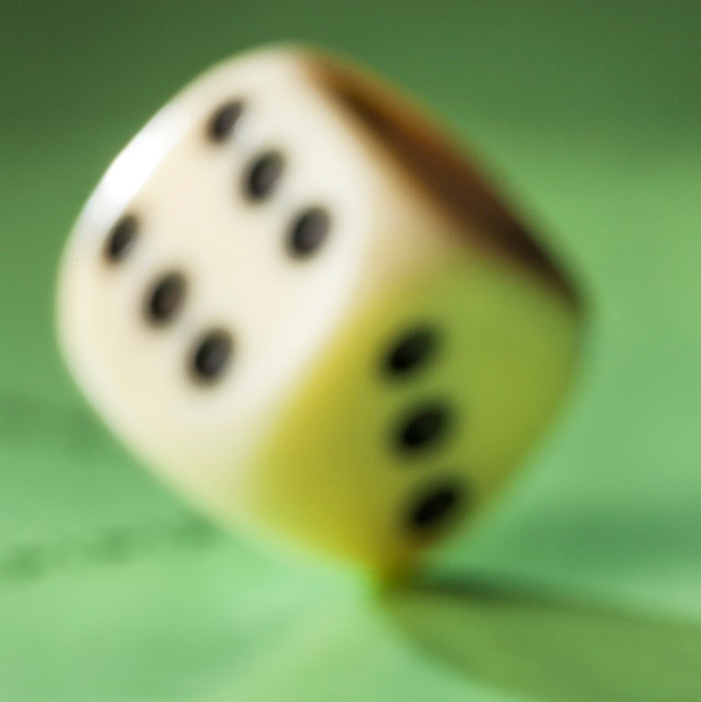

Sannolikhetsfunktion:

$P(\text{tärningen visar }x\text{ prickar})=\frac{1}{6}$ där $x=1,...,6$

Annat skrivsätt

$f(x)=P(X=x)=\frac{1}{6}$ där $x=1,...,6$

- Rita upp fördelningsfunktionen!
- Vad är sannolikheten att få minst femma?
- Vad är sannolikheten att få högst en tvåa?
- Vad förväntar vi oss att få för resultat på träningen “i genomsnitt”?

## Simulering av kast med tärning

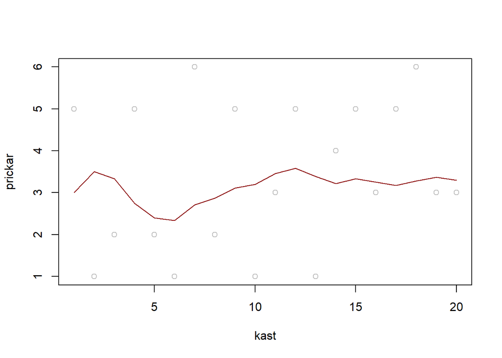

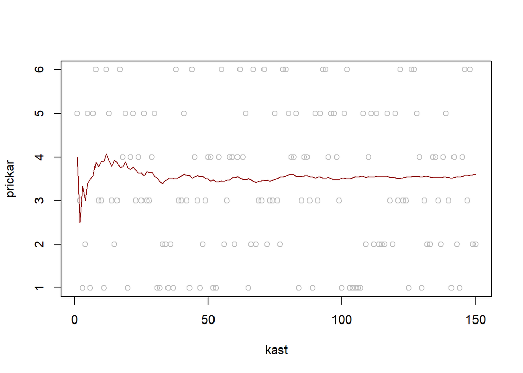

# Poissonfördelning

Vi använder Poissonfördelning när vi vill veta hur många gånger något händer under ett visst tidsintervall

- Antal bilar som passerar under en timme

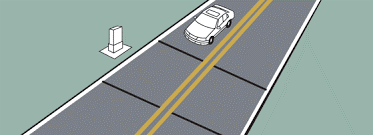

- Antal vulkanutbrott under 100 år
- Antal fåglar man ser när man går längs med ett transekt (linje)

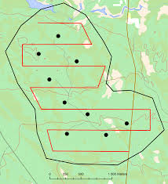

## Krav på Poissonfördelning

För att en slumpvariabel ska anses följa en Poissonfördelning måste följande gälla:

- Det sker i snitt lika många händelser per tidsenhet
- Antal händelser i icke överlappande intervall är oberoende
- Två händelser kan inte hända samtidigt

**Vulkanutbrott**

Det är tveksamt om antal vulkanutbrott under 100 år stämmer på dessa krav - vilket?

## Poisson-fördelning - Sannolikhetsfunktion

$X \sim Po(\lambda)$ (symbolen $\sim$ (“tilde”) och det som följer läses som “*är fördelad som en Poissonfördelning*”)

$\lambda$ (grekisk bokstav “lambda”) är parameter i sannolikhetsfunktionen

$f_X(x) = P(X = x)=\frac{e^{-\lambda}\cdot \lambda^x}{x!}$ där utfallsrummet består av alla icke-negativa heltal $x \in \{0,1,2,3,...\}$

[Poisson distribution on wikipedia](https://en.wikipedia.org/wiki/Poisson_distribution)

## Poissonfördelning

**Exempel. Poissonfördelning**

För ett antal år sedan slog en hudläkare larm att i ett område i Lund, beläget i närheten av en kemisk industri, var antalet fall av en sällsynt cancersjukdom ovanligt stort. I det aktuella området hade **nio personer** (sex kvinnor och tre män) drabbats av sjukdomen under en femårsperiod. Då läkaren studerade det rikstäckande cancerregistret såg han att i en population like astor som den i det aktuella området borde man under denna femårsperiod förväntat sig att antalet sjukdomsfall skulle vara fyra.

**Modell:** $X=$ “antalet sjuka i området under femårsperioden

$X\sim Po(\lambda=4)$

$P(\text{precis x sjuka}) = P(X=x) = f(x) = \frac{e^{-4}\cdot 4^x}{x!}$

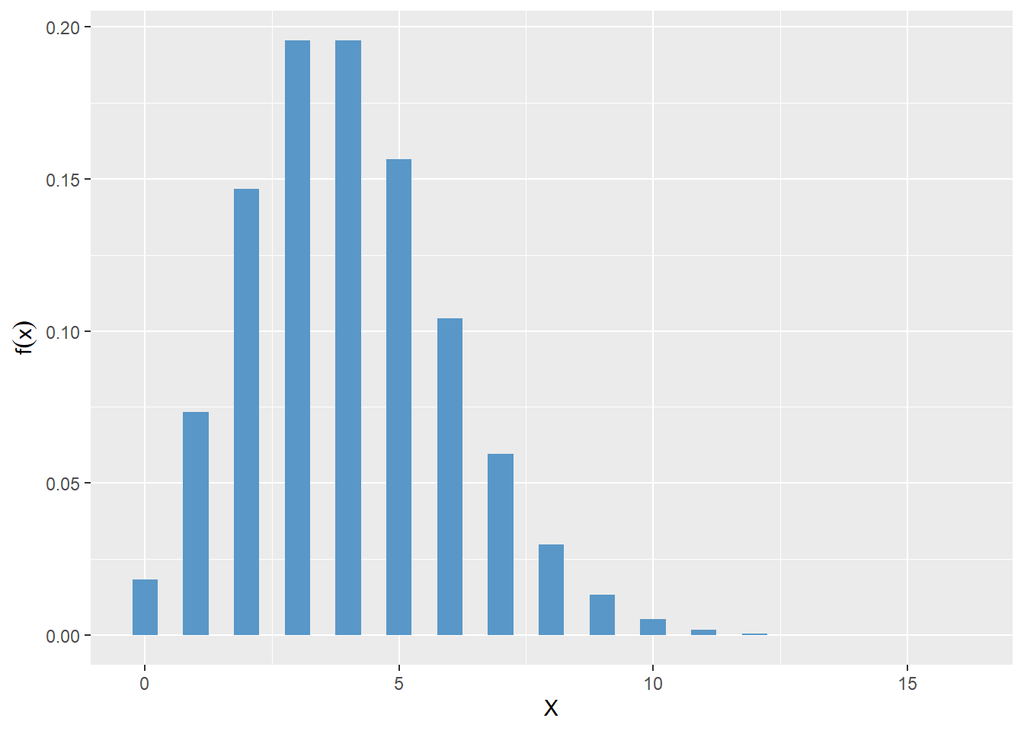

- Vad är sannolikheten att man observerar precis 5 sjuka?
- Vad är sannolikheten att man observerar högst 2 sjuka?
- Vad är sannolikheten att man observerar 9 eller fler sjuka?

### Exempel. Poissonfördelning

- Vad är sannolikheten att man observerar precis 5 sjuka?

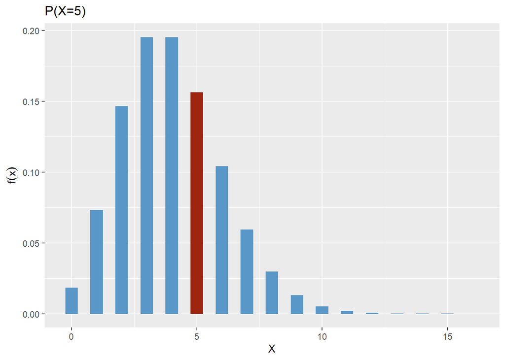

### Exempel. Poissonfördelning

- Vad är sannolikheten att man observerar högst 2 sjuka?

$P(X\leq 2) = P(X=0) + P(X = 1) + P(X = 2)$

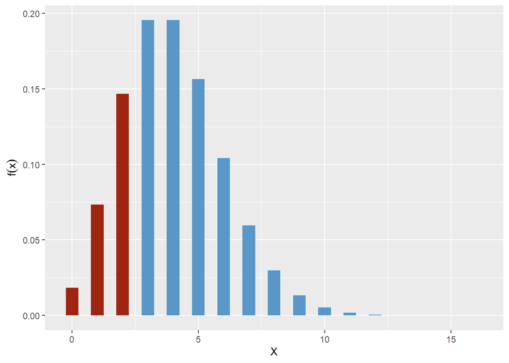

### Exempel. Poissonfördelning

- Vad är sannolikheten att man observerar 9 eller fler sjuka?

$P(X\geq 9) = P(X=9) + P(X = 10) + ....$

kan också skrivas som

$P(X\geq 9) = 1 - P(X \leq 8)$

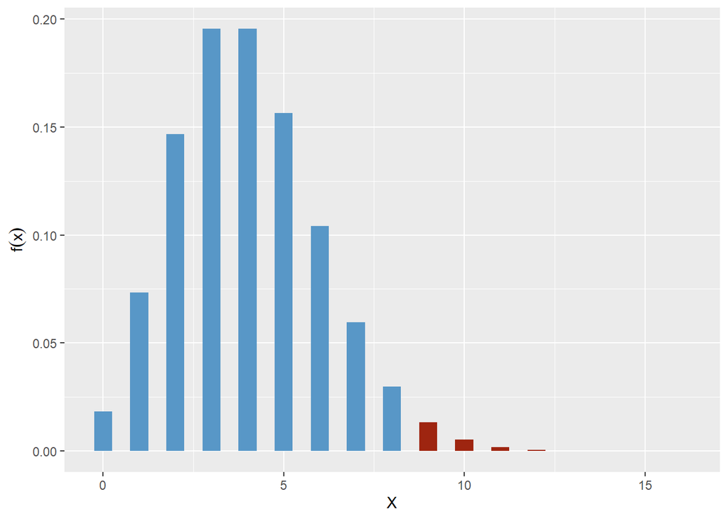

## Ta fram värdet på sannolikhet med hjälp av sannolikhetstabell

Tabell för fördelningsfunktionen för olika parametervärden.

$P(X \leq 8) = 0.97864$

$P(X \geq 9) = 1- P(X \leq 8) = 1 - 0.97864 = 0.02136$

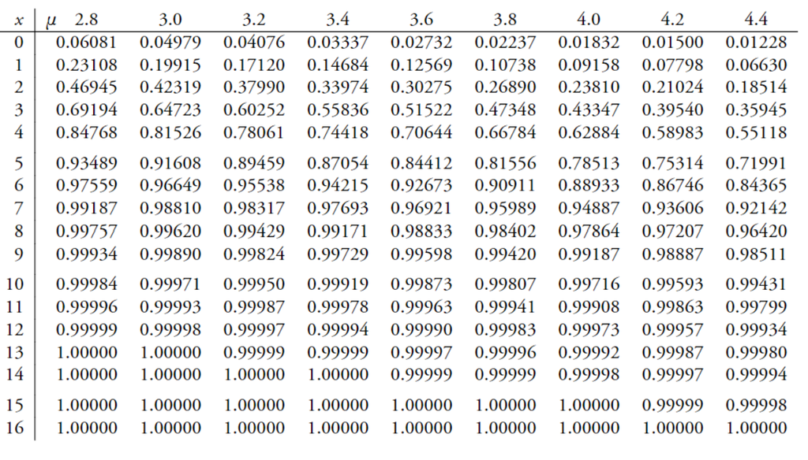

# Binomialfördelning

Binomialfördelningen uppstår när man gör $n$ oberoende försök och räknar antalet gånger som försöket ”lyckades”

**Exempel. Binomialfördelning**

- Du försöker träffa en papperskorg med 10 pappersbollar

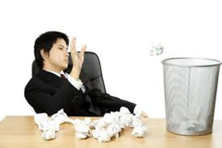

- Du kastar ett mynt 20 gånger och räknar hur många gånger du fick krona

## Binomialfördelning - försök till härledning av sannolikhetsfunktionen

Vi gör $n=10$ försök där sannolikheten att lyckas i ett försök är $p$

$X=$ “antal lyckade försök”

$P(X=0) = P(\text{misslyckats i 10 försök}) = (1-p)(1-p)\cdots (1-p) = (1-p)^{10}$

$P(X=1)$?

$X=1$ motsvarar att lyckas i ett försök och misslyckas i nio försök, där ordnigen inte spelar någon roll

lyckas i första försöket: $p(1-p)\dots (1-p) = p(1-p)^{9}$

detta kan ske på 10 sätt, vilket ger $P(X=1) = 10\cdot p(1-p)^{9}$

På samma sätt: $P(X=2) = \frac{10\cdot 9}{2}\cdot p^2(1-p)^8$

## Binomialfördelning - sannolikhetsfunktionen

$X \sim Bin(n,p)$

Parametrarna är $n$, antal försök, och $p$, sannolikheten att “lyckas” i ett försök.

$f_X(x) = P(X = x)== \frac{n!}{x!(n-x)!}p^x\cdot (1-p)^{n-x}$ där utfallsrummet består av heltal mellan 0 och $n$, d.v.s. $x \in \{0,1,2,3,...,n\}$

[Binomial distribution on wikipedia](https://en.wikipedia.org/wiki/Binomial_distribution)

## Binomialfördelning

**Exempel: Vi kastar en fyr-sidig tärning 7 gånger**

$X=$ “antal tärningar som visar en 1:a”

$X \sim Bin(n,p)$ där $n=7$ och $p=\frac{1}{4}$

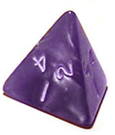

- Vad är sannolikheten att få fyra 1:or?

$P(X=4) = \binom{n}{x}p^x\cdot (1-p)^{n-x} = \binom{7}{4}\frac{1}{4}^4\cdot (1-\frac{1}{4})^{3}$

- Vad är sannolikheten att få högst fyra 1:or?

$P(X\leq 4) = \sum_{x = 0}^4 P(X=x) = \sum_{x = 0}^4 \binom{7}{x}\frac{1}{4}^{x}\cdot (\frac{3}{4})^{7-x}$

Jobbigt att räkna ut

## Ta fram värdet på sannolikhet med hjälp av sannolikhetstabell

Tabell för fördelningsfunktionen för olika parametervärden.

$P(X\leq 4) = 0.98712$

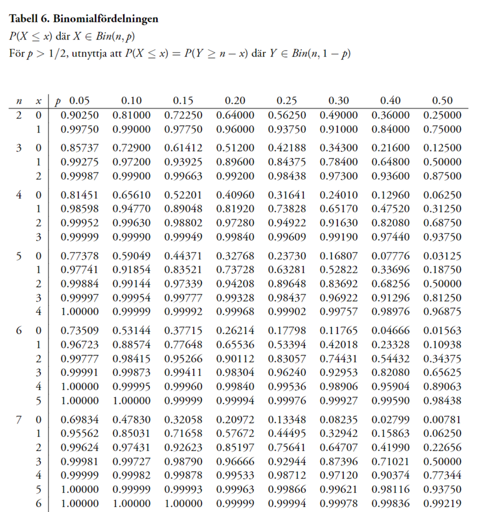

# Väntevärde och varians

Det finns flera sätt att sammanfatta den slumpmässiga variation som finns hos en slumpvariabel $X$

Mått på centralt läge:

- **Väntevärde** ”vilket värde som $X$ antar i snitt”
- $E(X)$ (E står för Expected value)
- $\mu$ (grekisk bokstav som uttalas *my*)

Mått på spridning:

- **Varians** - ”hur sprider sig värdena som $X$ antar kring väntevärdet”
- $V(X)$
- $\sigma^2$ (grekisk bokstav som uttalas *sigma* i kvadrat)
- **Standardavvikelse** - $\sqrt{V(X)}$
- $\sigma$

**Tip**

Alla slumpvariabler har väntevärde och varians som kan betecknas med $\mu$ och $\sigma^2$ oavsett vilken sannoliketsfördelning de tillhör.

T.ex. Väntevärde och varians för s.v. $X$ är $\mu_X$ och $\sigma^2_X$

Väntevärde och varians för s.v. $Y$ är $\mu_Y$ och $\sigma^2_Y$

# Väntevärde för en diskret slumpvariabel

$E(X) = \sum_{\text{alla }x} x\cdot P(X=x) = \sum_{\text{alla }x} x\cdot f(x)$

**Väntevärde för en likformig fördelning**

$E(X)=\sum_{x=1}^6 x\cdot \frac{1}{6} = \frac{1}{6} \cdot (1 + 2+ 3 +4+5+6) = 3.5$

## Väntevärde för en Poisson-fördelning

$X \sim Po(\lambda)$

$E(X) = \lambda$

I formelsamlingen heter parametern för Poissonfördelningen $\mu$

## Väntevärde för en Binomialfördelning

$X \sim Bin(n,p)$

$E(X) = n\cdot p$

# Väntevärde av en funktion av en slumpvariabel

$g(x)$ är en funktion

$E(g(X)) = \sum_{\text{alla }x} g(x)\cdot f(x)$

*sannolikhetsfunktionen förändras inte för transformerade värden*